# Simulation Methods: Lab 1

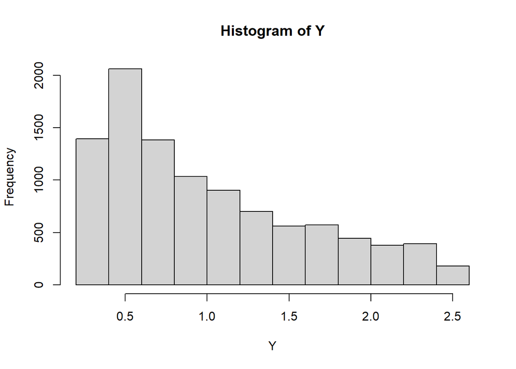

```r
w <- function(x) dunif(x, 0, 10)/dnorm(x, mean=5, sd=1) # weights -> f/g
f <- function(x) 10*exp(-2*abs(x-5)) # f() function (h() in literature)
X <- rnorm(10000,mean=5,sd=1) # sampling for X from normal distribution that is: the envelope distr. g()
Y <- w(X)*f(X) # weighting in the samples.


hist(Y)
```

```r
summary(Y)
```

```
##    Min. 1st Qu.  Median    Mean 3rd Qu.    Max.
##  0.3392  0.4987  0.8296  1.0093  1.4116  2.5136
```

2. The next task is to transform the IS algorithm into a Sampling importance resampling (SIR) algorithm following the lecture notes (and course literature) and compare the results with these from a). Use the same n and choose m according to recommendations. Discuss the results and provide code with explanations.

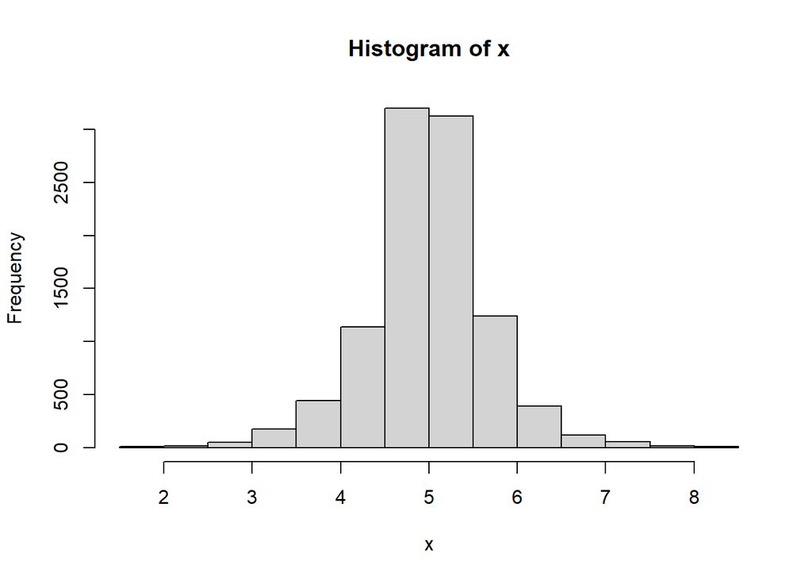

```r
w <- function(x) f(x)/dnorm(x, mean=5, sd=1) # weights -> f/g


set.seed(1234) #set seet for reproducabilituy
n <- 10000 # n. of observatiosn
m <- 5000 # n. of samples

y <- rnorm(n = m, mean = 5, sd = 1) # take samples from the envelope
w <-  w(y) # calculate weights
w <- w/sum(w) # norm the weights

x <- sample(y, replace = TRUE, prob = w, size = n) # resample from envelope with the weights as probabilities

hist(x) # let's see what was created
```

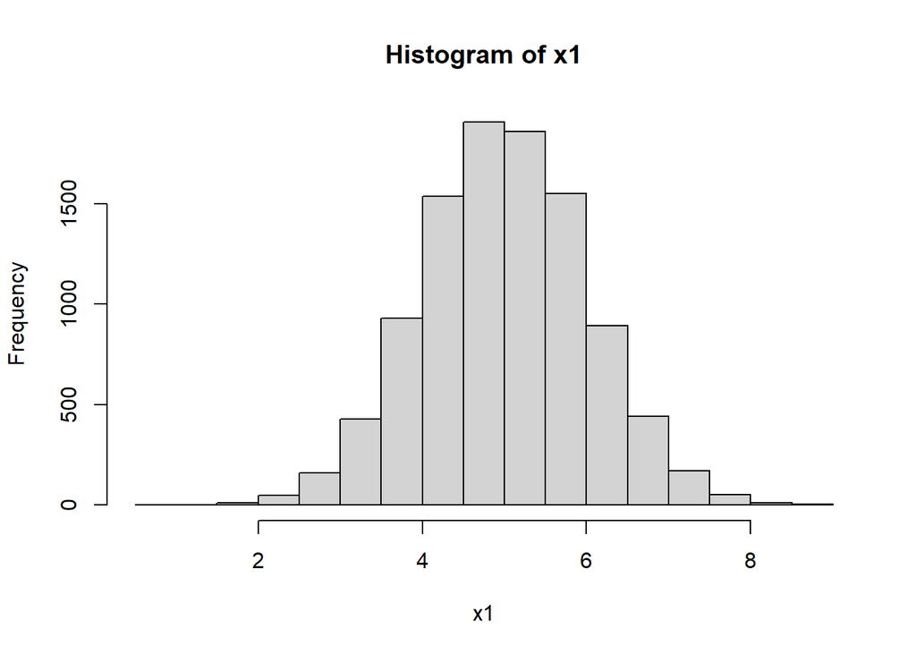

```r
x1 <- rnorm(n, mean = 5, 1)

hist(x1)
```

Compared to the SIR sample, this looks bloated with larger variance in its sample.

let’s take at the variance difference between the two

```r
var(x)
```

```
## [1] 0.4798804
```

```r
var(x1)
```

```
## [1] 0.9945222
```

SIR sampled has almost half the variance of the normal sample.